# Consumo de Combustíveis — Relatório

[figure not shown]

```r
dados_2021_et <- dados |>
  filter(Ano == 2020, tipo == "diesel") |>
  group_by(uf_sigla, pop) |>
  summarise(Volume = sum(Volume, na.rm = TRUE), .groups = "keep") |>
  mutate(volume_pc = Volume / pop)

ufs <- geobr::read_state(year = 2020, simplified = TRUE) |>
  select(abbrev_state, name_state, geom)

mapa <- ufs |>
  left_join(dados_2021_gas, by = c("abbrev_state" = "uf_sigla"))

ggplot(mapa) +
  geom_sf(aes(fill = Volume), color = "white", size = .1) +
  scale_fill_viridis_c(na.value = "grey90", name = "m³/pop") +
  labs(title = "Consumo de Diesel por UF — 2020") +
  theme_minimal()
```

## Share – 2020

```r
# Totais por UF (um valor por UF)
base_uf <- dados |>
  filter(Ano == 2020, uf_sigla != "BR") |>
  group_by(uf_sigla,tipo) |>
  summarise(Volume = sum(Volume, na.rm = TRUE), .groups = "drop")

total_vol <- sum(base_uf$Volume, na.rm = TRUE)

total_vol <- base_uf |>
  group_by(tipo) |>
  summarise(
    total_vol_tipo = sum(Volume)
  )


# Participação por região (totais)
regioes <- base_uf |>
  group_by(tipo) |>
  mutate(Volume_total = sum(Volume, na.rm = TRUE)) |>
  mutate(share = Volume / Volume_total)


tab_gasolina <- regioes |>
  filter(tipo == "gasolina") |>
  arrange(desc(share))

tab_etanol <- regioes |>
  filter(tipo == "etanol") |>
  arrange(desc(share))

tab_diesel <- regioes |>
  filter(tipo == "diesel") |>
  arrange(desc(share))

knitr::kable(tab_gasolina, caption = "Totais e participação por UF — Gasolina")
```

Totais e participação por UF — Gasolina

| uf_sigla | tipo | Volume | Volume_total | share |
| --- | --- | --- | --- | --- |
| SP | gasolina | 7176931.3 | 15484802 | 0.4634823 |
| MG | gasolina | 3239443.3 | 15484802 | 0.2092015 |
| PA | gasolina | 1208775.2 | 15484802 | 0.0780620 |
| GO | gasolina | 1131572.9 | 15484802 | 0.0730764 |
| DF | gasolina | 946625.4 | 15484802 | 0.0611325 |
| MA | gasolina | 926654.7 | 15484802 | 0.0598429 |
| MT | gasolina | 501812.8 | 15484802 | 0.0324068 |
| TO | gasolina | 352986.1 | 15484802 | 0.0227956 |

```r
knitr::kable(tab_etanol,  caption = "Totais e participação por UF — Etanol")
```

Totais e participação por UF — Etanol

| uf_sigla | tipo | Volume | Volume_total | share |
| --- | --- | --- | --- | --- |
| SP | etanol | 10139688.62 | 15627997 | 0.6488156 |
| MG | etanol | 2743683.85 | 15627997 | 0.1755621 |
| GO | etanol | 1557748.93 | 15627997 | 0.0996768 |
| MT | etanol | 915611.40 | 15627997 | 0.0585879 |
| DF | etanol | 149771.10 | 15627997 | 0.0095835 |
| PA | etanol | 44085.35 | 15627997 | 0.0028209 |
| MA | etanol | 39181.08 | 15627997 | 0.0025071 |
| TO | etanol | 38226.92 | 15627997 | 0.0024461 |

```r
knitr::kable(tab_diesel,  caption = "Totais e participação por UF — Diesel")
```

Totais e participação por UF — Diesel

| uf_sigla | tipo | Volume | Volume_total | share |
| --- | --- | --- | --- | --- |
| SP | diesel | 12111972.8 | 30768993 | 0.3936422 |
| MG | diesel | 6991245.5 | 30768993 | 0.2272172 |
| MT | diesel | 3173373.3 | 30768993 | 0.1031354 |
| GO | diesel | 2958580.8 | 30768993 | 0.0961546 |
| PA | diesel | 2617836.0 | 30768993 | 0.0850803 |
| MA | diesel | 1436736.1 | 30768993 | 0.0466943 |
| TO | diesel | 1128562.6 | 30768993 | 0.0366786 |
| DF | diesel | 350685.8 | 30768993 | 0.0113974 |

O mercado de gasolina é bem concentrado: São Paulo (46,3%) e Minas Gerais (20,9%) somam cerca de 67%. Com Pará (7,8%) e Goiás (7,3%), os quatro maiores chegam a ~82% do total. Entre as demais UFs listadas, DF (6,1%), Maranhão (6,0%), Mato Grosso (3,2%) e Tocantins (2,3%).

O mercado de etanol é extremamente concentrado: São Paulo responde por 64,9%, Minas Gerais por 17,6%, Goiás por 10,0% e Mato Grosso por 5,9% — juntos, 98,3% do total. As demais UFs listadas (DF, PA, MA e TO) têm menos de 1% cada e somam 1,7%.

O mercado de diesel somou é fortemente concentrado: São Paulo (39,4%) e Minas Gerais (22,7%) respondem juntos por cerca de 62%. Somando Mato Grosso (10,3%) e Goiás (9,6%), os quatro maiores chegam a ~82% do total. Entre Norte e Nordeste, destacam-se Pará (8,5%), Maranhão (4,7%) e Tocantins (3,7%), enquanto o Distrito Federal tem participação residual (1,1%).

# 5 Evolução Consumo últmos 5 anos (por UF)

Os dados foram analisados excluindo 2021, devido à falta de valores deste ano. Como podemos observar os graficos abaixos, dos três combustíveis nos ultimos 5 anos, apenas a gasolina perdeu caiu em venda. Tanto o etanol, quanto o diesel, tiveram um aumento.

## 5.1 Gasolina

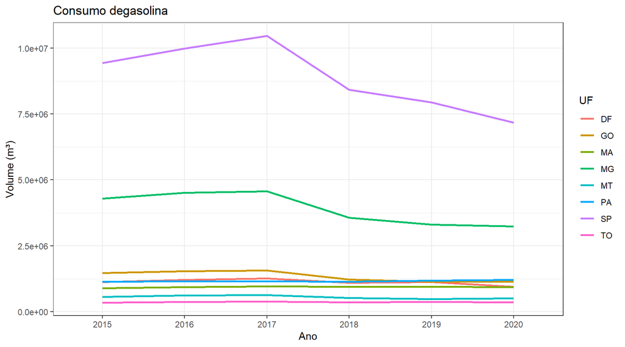

```r
combustivel_alvo <- "gasolina"

serie <- dados |>
  filter(tipo == combustivel_alvo, uf_sigla != "BR", Ano < 2021, Ano > 2014) |>
  group_by(uf_sigla, Ano, pop) |>
  summarise(consumo = sum(Volume, na.rm = TRUE), .groups = "keep") |>
  mutate(consumo_pc = consumo / pop)

ggplot(
  serie,
  aes(x = Ano, y = consumo, group = uf_sigla, color = factor(uf_sigla))
) +
  geom_line(linewidth = 0.9) +
  labs(
    title = paste0("Consumo de", combustivel_alvo),
    y = "Volume (m³)",
    color = "UF"
  ) +
  theme_bw()
```

## 5.2 Etanol

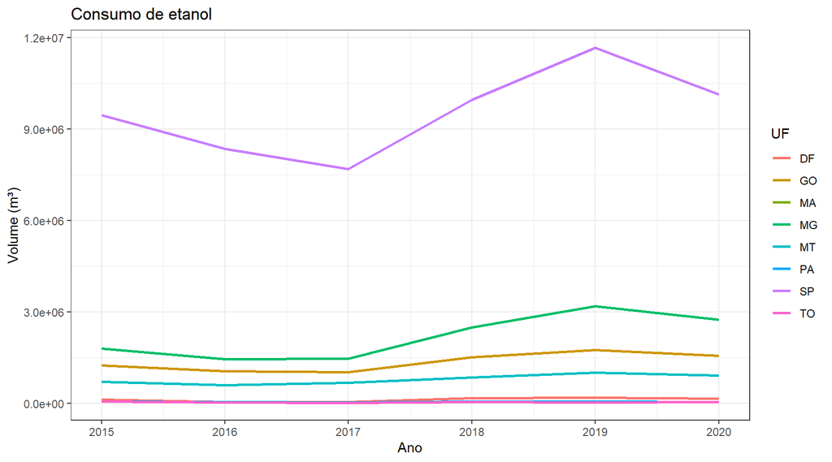

```r
combustivel_alvo <- "etanol"

serie <- dados |>
  filter(tipo == combustivel_alvo, uf_sigla != "BR", Ano < 2021, Ano > 2014) |>
  mutate(Ano = as.numeric(Ano)) |>
  group_by(uf_sigla, Ano) |>
  summarise(consumo = sum(Volume, na.rm = TRUE), .groups = "drop")

ggplot(
  serie,
  aes(x = Ano, y = consumo, group = uf_sigla, color = factor(uf_sigla))
) +
  geom_line(linewidth = 0.9) +
  labs(
    title = paste0("Consumo de ", combustivel_alvo),
    y = "Volume (m³)",
    color = "UF"
  ) +
  theme_bw()
```

## 5.3 Diesel

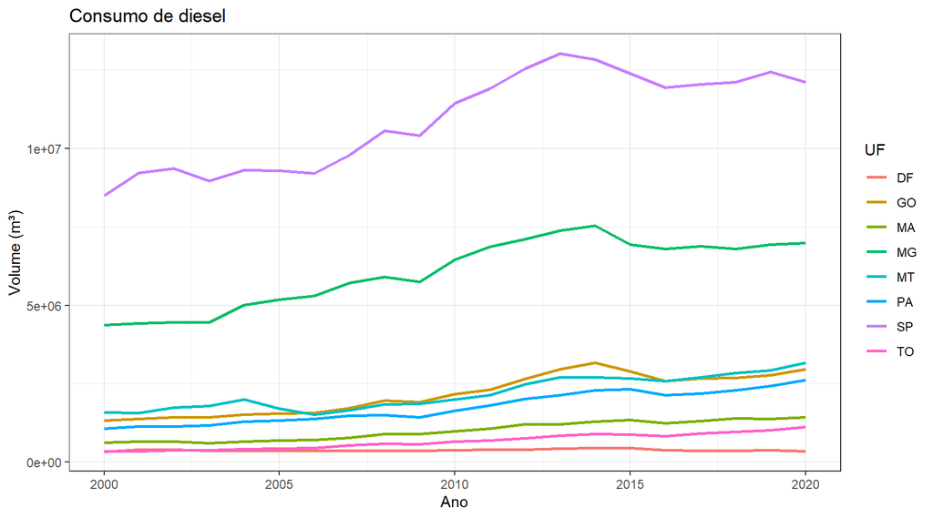

```r
combustivel_alvo <- "diesel"

serie <- dados |>
  filter(tipo == combustivel_alvo, uf_sigla != "BR", Ano < 2021) |>
  mutate(Ano = as.numeric(Ano)) |>
  group_by(uf_sigla, Ano) |>
  summarise(consumo = sum(Volume, na.rm = TRUE), .groups = "drop")

ggplot(
  serie,
  aes(x = Ano, y = consumo, group = uf_sigla, color = factor(uf_sigla))
) +
  geom_line(linewidth = 0.9) +
  labs(
    title = paste0("Consumo de ", combustivel_alvo),
    y = "Volume (m³)",
    color = "UF"
  ) +
  theme_bw()
```

## 5.4 Tamanho do mercado (últimos 5 anos)

```r
vol_ano_total <- dados |>
  filter(uf_sigla == "BR") |>
  mutate(Ano = as.integer(Ano)) |>
  group_by(Ano, tipo) |>
  summarise(volume_total = sum(Volume, na.rm = TRUE), .groups = "drop")

ult_ano = 2020
janela  <- ( 2020- 4):ult_ano

vol5_tipo <- vol_ano_total |>
  filter(Ano %in% janela)

cagr_5a <- vol5_tipo |>
  arrange(Ano) |>
  group_by(tipo) |>
  summarise(cagr = (last(volume_total) / first(volume_total))^(1 / (5 - 1)) - 1)

tab <- vol5_tipo |>
  select(tipo, Ano, volume_total) |>
  pivot_wider(names_from = Ano, values_from = volume_total) |>
  left_join(cagr_5a, by = "tipo")

knitr::kable(tab, caption = "Volumes (m³) por tipo e ano, com CAGR (5 anos)")
```

Volumes (m³) por tipo e ano, com CAGR (5 anos)

| tipo | 2016 | 2017 | 2018 | 2019 | 2020 | cagr |
| --- | --- | --- | --- | --- | --- | --- |
| diesel | 54278570 | 54772292 | 55629467 | 57298448 | 57472056 | 0.0143950 |
| etanol | 14585844 | 13641774 | 19384719 | 22544050 | 19257933 | 0.0719376 |
| gasolina | 43019082 | 44149532 | 38351779 | 38165037 | 35823614 | -0.0447280 |

Diesel — Em 2020, o mercado totalizou 57.472.056 m³ (≈ 57,5 bilhões de litros). De 2016 a 2020, cresceu à taxa geométrica de 1,4% a.a.

Etanol — Em 2020, o mercado totalizou 19.257.933 m³ (≈ 19,3 bilhões de litros). De 2016 a 2020, cresceu à taxa geométrica de 7,2% a.a.

Gasolina — Em 2020, o mercado totalizou 35.823.614 m³ (≈ 35,8 bilhões de litros). De 2016 a 2020, recuou à taxa geométrica de 4,5% a.a.